# Exploratory Data Analysis: `swiss`

Eugene Joh

Wednesday, December 05, 2018

# Overview

This parameterized markdown file is a standarized exploratory analysis report, examining the data type, structure, missing values, unique values, summary statistics for continuous and categorical variables contained within a `data.frame` object.

This does not support `date-time` varaibles such as `POSIXct` or `Date`, but will eventually move to support all data types typically found in `data.frame` in the R environment.

# Data Structure

Dataset Dimensions

| Name | Number of Columns | Number of Rows | Number of Elements | Memory Allocation |
| --- | --- | --- | --- | --- |
| swiss | 7 | 47 | 329 | 6.5 Kb |

Dataset Variable Class and Missing Values

| Variable | Class | missing |
| --- | --- | --- |
| location | character | 0 |
| Fertility | numeric | 0 |
| Agriculture | numeric | 0 |
| Examination | integer | 0 |
| Education | integer | 0 |
| Catholic | numeric | 0 |
| Infant.Mortality | numeric | 0 |

# Missing Values, Data Type, Unique Values

## Table

The table below displays the data type, counts/proportion of missing values `NA`, and whether the data is labelled or not.

|  | Variable | Missing (n) | Missing (%) | Exist (%) | Data Type | Labelled |
| --- | --- | --- | --- | --- | --- | --- |
| 1 | location | 0 | 0 | 100 | character | False |
| 2 | Fertility | 0 | 0 | 100 | numeric | False |
| 3 | Agriculture | 0 | 0 | 100 | numeric | False |
| 4 | Examination | 0 | 0 | 100 | integer | False |
| 5 | Education | 0 | 0 | 100 | integer | False |
| 6 | Catholic | 0 | 0 | 100 | numeric | False |
| 7 | Infant.Mortality | 0 | 0 | 100 | numeric | False |

## Plot

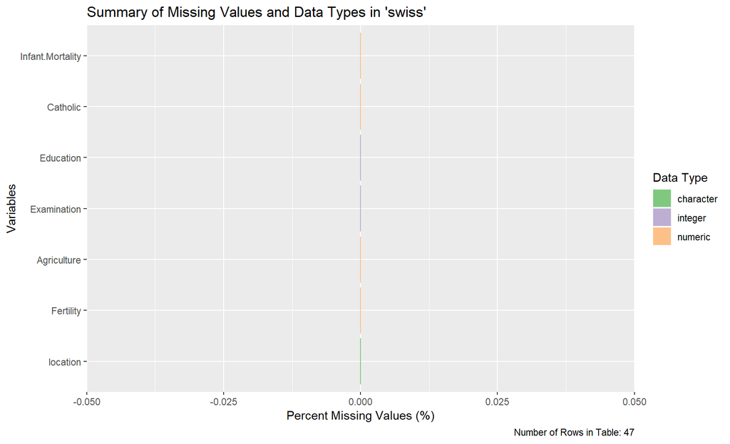

## Unique Values

|  | Variable | Counts | Percentage of Total Rows |
| --- | --- | --- | --- |
| 1 | location | 47 | 100 |
| 2 | Fertility | 46 | 97.87 |
| 3 | Agriculture | 47 | 100 |
| 4 | Examination | 22 | 46.81 |
| 5 | Education | 19 | 40.43 |
| 6 | Catholic | 46 | 97.87 |
| 7 | Infant.Mortality | 37 | 78.72 |

# Variable Content

This section contains an analysis of the variable content composition by describing the type of data content that exist based on **numeric** values, **character** values, **punctuation** or **symbols**, and **blank** space. This is especially useful when data types are not identified or misclassified.

## Only Numbers

**only_numbs** reports the number of rows that contain only digits `"^[0-9]{1,}$"` and **numpercent** is the respective percentage. **digits_min** and **digits_max** display the length of the digits found in the variable, **digits_eq** is a logical statment of whether the mix and max are equal.

|  | variable | only_numbs | n_row | numpercent | digits_min | digits_max | digits_eq |
| --- | --- | --- | --- | --- | --- | --- | --- |
| 1 | location | 0 | 47 | 0 |  |  | False |
| 2 | Fertility | 47 | 47 | 100 | 2 | 2 | True |
| 3 | Agriculture | 47 | 47 | 100 | 2 | 2 | True |
| 4 | Examination | 47 | 47 | 100 | 1 | 2 | False |
| 5 | Education | 47 | 47 | 100 | 1 | 2 | False |
| 6 | Catholic | 47 | 47 | 100 | 3 | 3 | True |
| 7 | Infant.Mortality | 47 | 47 | 100 | 2 | 2 | True |

## Only Character

**only_char** reports the number of rows that contain only characters `"^[A-z]{1,}"` and **charpercent** is the respective percentage.

|  | variable | only_char | n_row | charpercent |
| --- | --- | --- | --- | --- |
| 1 | location | 37 | 47 | 78.723 |
| 2 | Fertility | 0 | 47 | 0 |
| 3 | Agriculture | 0 | 47 | 0 |
| 4 | Examination | 0 | 47 | 0 |
| 5 | Education | 0 | 47 | 0 |
| 6 | Catholic | 0 | 47 | 0 |
| 7 | Infant.Mortality | 0 | 47 | 0 |

## Only Punctuation

**only_punc** reports the number of rows that contain only punctuation or symbols `"^\\W+$"` and **puncpercentage** is the respective percentage.

|  | variable | only_punc | n_row | puncpercent |
| --- | --- | --- | --- | --- |
| 1 | location | 0 | 47 | 0 |
| 2 | Fertility | 0 | 47 | 0 |
| 3 | Agriculture | 0 | 47 | 0 |
| 4 | Examination | 0 | 47 | 0 |
| 5 | Education | 0 | 47 | 0 |
| 6 | Catholic | 0 | 47 | 0 |
| 7 | Infant.Mortality | 0 | 47 | 0 |

## Only Blanks

**only_blanks** reports the number of rows that contain a blank ("") `"^\\s{0}$"` and **blankspercent** is the respective percentage. **only_wspace** reports the number of rows that contain any white-space, including a blank `"^\\s*$"` and **wspacepercent** is the respective percentage.

|  | variable | only_blanks | blankspercent | only_wspace | wspacepercent |
| --- | --- | --- | --- | --- | --- |
| 1 | location | 0 | 0 | 0 | 0 |
| 2 | Fertility | 0 | 0 | 0 | 0 |
| 3 | Agriculture | 0 | 0 | 0 | 0 |
| 4 | Examination | 0 | 0 | 0 | 0 |
| 5 | Education | 0 | 0 | 0 | 0 |
| 6 | Catholic | 0 | 0 | 0 | 0 |
| 7 | Infant.Mortality | 0 | 0 | 0 | 0 |

## All Types

|  | variable | only_numbs | numpercent | digits_min | digits_max | digits_eq | only_char | charpercent | only_punc | puncpercent | only_blanks | blankspercent | only_wspace | wspacepercent |
| --- | --- | --- | --- | --- | --- | --- | --- | --- | --- | --- | --- | --- | --- | --- |
| 1 | location | 0 | 0 |  |  | False | 37 | 78.723 | 0 | 0 | 0 | 0 | 0 | 0 |
| 2 | Fertility | 47 | 100 | 2 | 2 | True | 0 | 0 | 0 | 0 | 0 | 0 | 0 | 0 |
| 3 | Agriculture | 47 | 100 | 2 | 2 | True | 0 | 0 | 0 | 0 | 0 | 0 | 0 | 0 |
| 4 | Examination | 47 | 100 | 1 | 2 | False | 0 | 0 | 0 | 0 | 0 | 0 | 0 | 0 |
| 5 | Education | 47 | 100 | 1 | 2 | False | 0 | 0 | 0 | 0 | 0 | 0 | 0 | 0 |
| 6 | Catholic | 47 | 100 | 3 | 3 | True | 0 | 0 | 0 | 0 | 0 | 0 | 0 | 0 |
| 7 | Infant.Mortality | 47 | 100 | 2 | 2 | True | 0 | 0 | 0 | 0 | 0 | 0 | 0 | 0 |

# Variable Content Plot

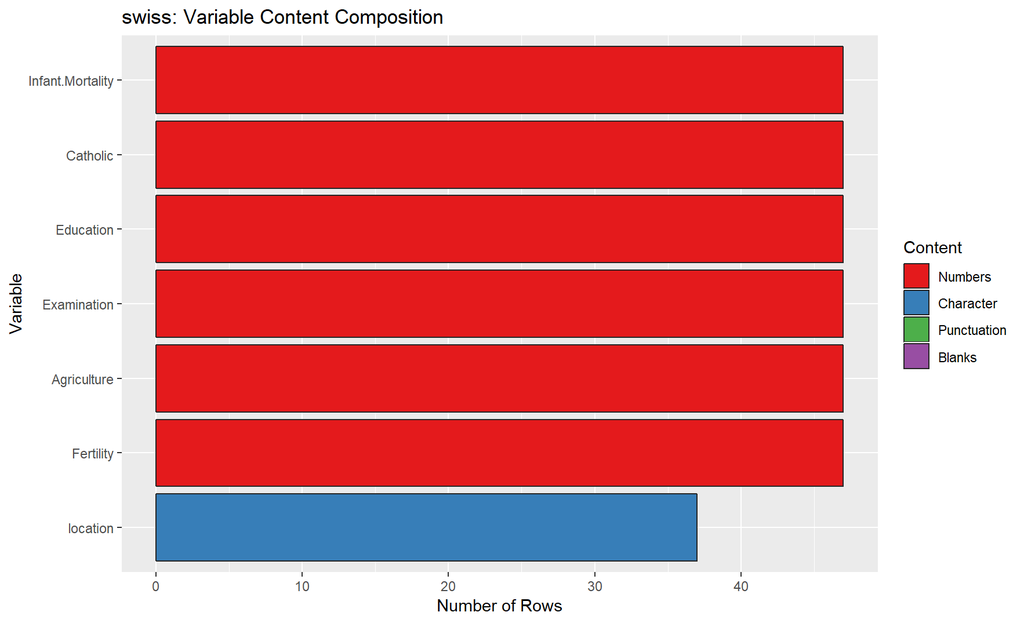

# Continuous Variables

## ‘Fertility’

Summary Statistics for Fertility

| Min | Mean | Median | Max | Standard Deviation |
| --- | --- | --- | --- | --- |
| 35 | 70.14 | 70.4 | 92.5 | 12.49 |

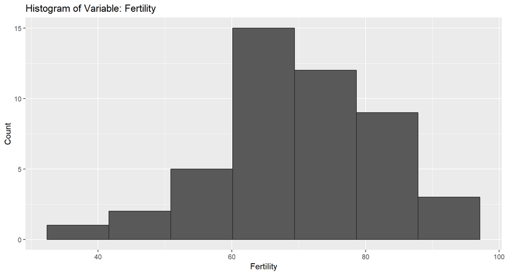

## ‘Agriculture’

Summary Statistics for Agriculture

| Min | Mean | Median | Max | Standard Deviation |
| --- | --- | --- | --- | --- |
| 1.2 | 50.66 | 54.1 | 89.7 | 22.71 |

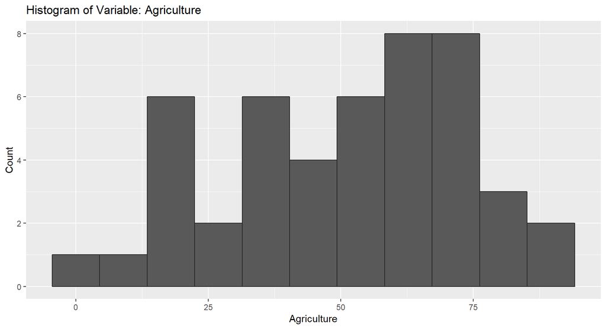

## ‘Examination’

Summary Statistics for Examination

| Min | Mean | Median | Max | Standard Deviation |
| --- | --- | --- | --- | --- |
| 3 | 16.49 | 16 | 37 | 7.98 |

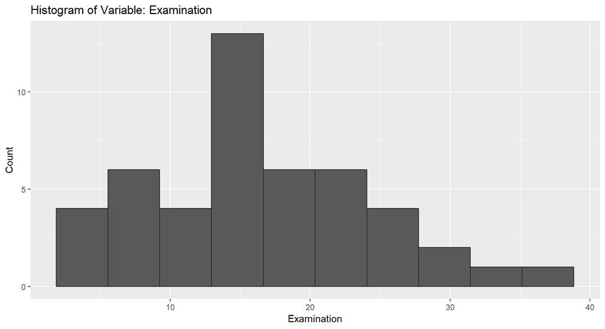

## ‘Education’

Summary Statistics for Education

| Min | Mean | Median | Max | Standard Deviation |
| --- | --- | --- | --- | --- |
| 1 | 10.98 | 8 | 53 | 9.62 |

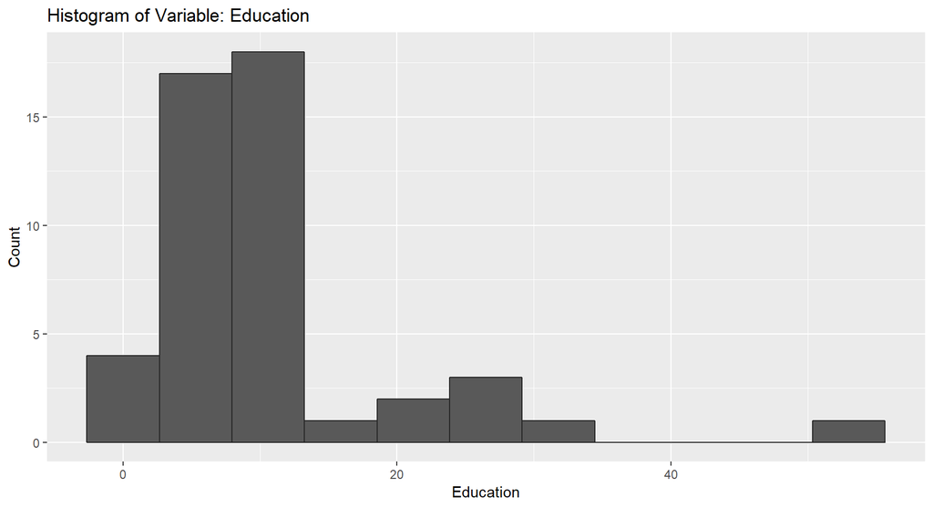

## ‘Catholic’

Summary Statistics for Catholic

| Min | Mean | Median | Max | Standard Deviation |
| --- | --- | --- | --- | --- |
| 2.15 | 41.14 | 15.14 | 100 | 41.7 |

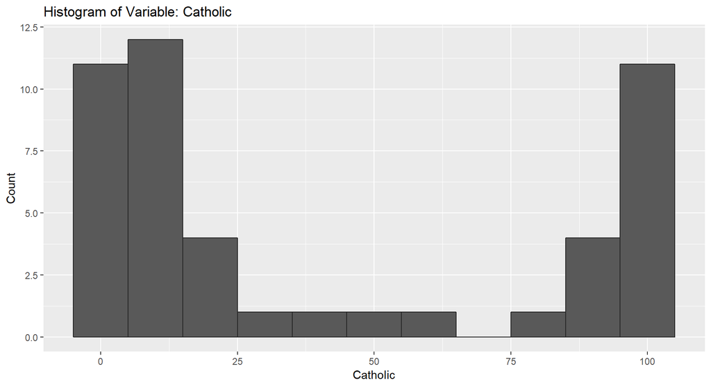

## ‘Infant.Mortality’

Summary Statistics for Infant.Mortality

| Min | Mean | Median | Max | Standard Deviation |
| --- | --- | --- | --- | --- |
| 10.8 | 19.94 | 20 | 26.6 | 2.91 |

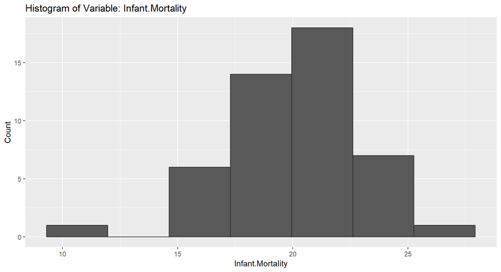

# Categorical Variables

## ‘location’

|  | location | n | percent |
| --- | --- | --- | --- |
| 1 | Aigle | 1 | 2.13 |
| 2 | Aubonne | 1 | 2.13 |
| 3 | Avenches | 1 | 2.13 |
| 4 | Boudry | 1 | 2.13 |
| 5 | Broye | 1 | 2.13 |
| 6 | Conthey | 1 | 2.13 |
| 7 | Cossonay | 1 | 2.13 |
| 8 | Courtelary | 1 | 2.13 |
| 9 | Delemont | 1 | 2.13 |
| 10 | Echallens | 1 | 2.13 |

[output cut: 37 more lines]

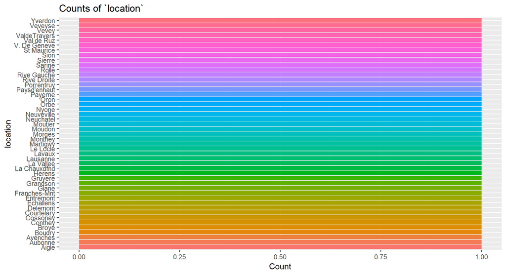

Process Time: 0.4 minutes  
R version 3.5.1 (2018-07-02)